# Johansen_Van_Topic_5

Description: This assignment mixes theory and application, in the form of two problems. Perform the tasks described in each. Note that this (and other) assignments includes a few challenging research-related tasks. They are aimed at gradually building your capacity to tackle complex topics, familiarize yourself with academic discourse, and provide context and practice for the skills you will eventually need when working on your capstone thesis or project.

APA style is expected, as well as formal and rigorous scientific writing, using appropriate mathematical notation and references.

### Part 1 – Decisions

- Note that on 9 days, the decision is made to drive a car, whereas on the remaining 5 days, the decision is negative about driving a car.

Consult the decision tree package, https://scikit-learn.org/stable/modules/tree.html and using a Jupyter notebook, implement the following in Python:

1. Calculate the information gain for x1, x2 and x3.
2. Choose the root node for the decision tree.
3. Plot a partial decision tree from root node along with training examples sorted to each of its descendent nodes.
4. You are required to continue with the decision-tree growing process until all nodes are pure (they contain examples that all have the same classification).
5. Will it be possible to reach this situation for the given dataset? If not, why not? (Hint: Look for inconsistencies in the given dataset.)
6. Summarize the entire work in a technical report.

### Part 2 – Fuzzy Decisions

You are tasked to modify the classifier tree in Part 1 so that it better mimics the way a human makes decisions. You will accomplish this by transforming the decision tree into a fuzzy decision tree.

In addition to the readings assigned in this topic, you may find it useful to read the techniques described in the "Combined Application of Decision Tree and Fuzzy Logic Techniques for Intelligent Grading of Dried Figs."

Answer the following and provide necessary Python code to help visualize your model:

1. Explain how you will fuzzify the attributes x1, x2 and x3.
2. Choose the root node for the fuzzy decision tree and defend your choice.
3. Plot a partial fuzzy decision tree from root node along with training examples sorted to each of its descendent nodes. Assume the dataset to be crisp, i.e., all membership functions satisfy:
   - µD(s(i)) = 1
1. As with Part 1, create a second report, detailing your approach to fuzzification of the decision tree.

```python
# import libraries and read in data

import pandas as pd
import numpy as np
from sklearn.tree import DecisionTreeClassifier, export_graphviz
from sklearn import tree
from matplotlib import pyplot as plt
from sklearn.ensemble import RandomForestClassifier

df = pd.read_csv('t5_dataset.csv')
df.set_index('Index', inplace=True)
df.head()
```

| Index | Temp | Wind | Traffic | Car |
| --- | --- | --- | --- | --- |
| 1 | hot | weak | long | no |
| 2 | hot | strong | long | no |
| 3 | hot | weak | long | yes |
| 4 | mild | weak | long | yes |
| 5 | cool | weak | short | yes |

```python
# get dummy variables for all features

df1 = pd.get_dummies(df)
df1.columns
```

```
Index(['Temp_cool', 'Temp_hot', 'Temp_mild', 'Wind_strong', 'Wind_weak',
       'Traffic_long', 'Traffic_short', 'Car_no', 'Car_yes'],
      dtype='object')
```

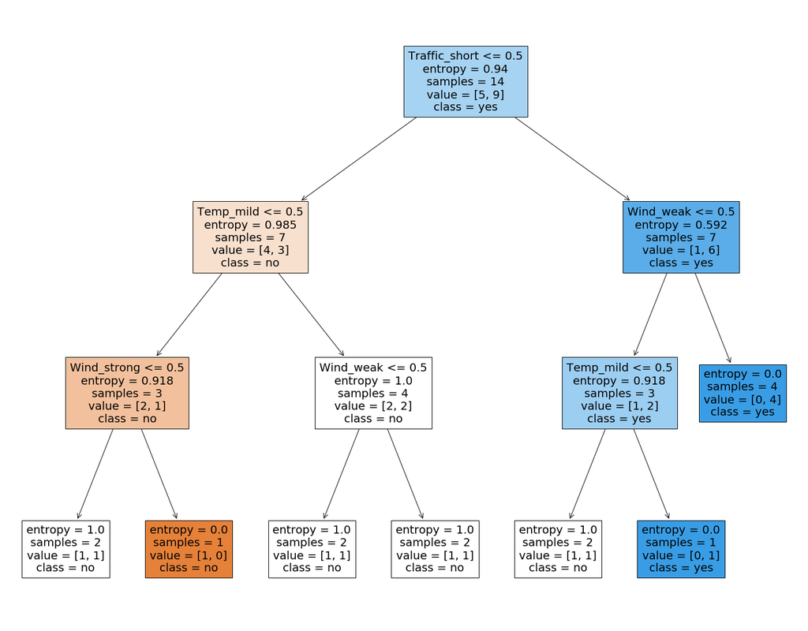

```python
# build decision tree

y = df['Car']
X = df1.drop(['Car_no', 'Car_yes'], axis=1)
dtree01 = DecisionTreeClassifier(criterion = "entropy").fit(X,y)

y_names = ['no','yes']
x_names = X.columns
fig = plt.figure(figsize=(25,20))
tree.plot_tree(dtree01, feature_names=x_names, class_names=y_names, filled=True)
plt.show()
```

```python
# fuzzify features - create rules

car = []
for row in range(0,len(df1)):
    if df1.iloc[row]['Wind_strong'] == 1 and df1.iloc[row]['Temp_hot'] == 1:
        car.append('yes')
    elif df1.iloc[row]['Wind_strong'] == 1 and df1.iloc[row]['Traffic_long'] == 1:
        car.append('yes')
    elif df1.iloc[row]['Temp_hot'] == 1 and df1.iloc[row]['Traffic_long'] == 1:
        car.append('yes')
    else:
        car.append('no')

df1['y'] = car
```

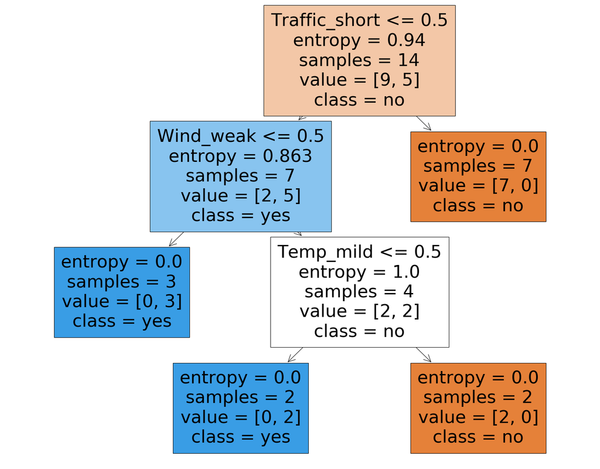

```python
# build fuzzy decision tree

y = df1['y']
X = df1.drop(['Car_no', 'Car_yes','y'], axis=1)
dtree02 = DecisionTreeClassifier(criterion = "entropy").fit(X,y)

y_names = ['no','yes']
x_names = X.columns
fig = plt.figure(figsize=(25,20))
tree.plot_tree(dtree02,feature_names=x_names, class_names=y_names, filled=True)
plt.show()
```